# Random Sample vs Time Series

[Nao Mimoto](https://nmimoto.github.io/) - [Dept. of Statistics](http://www.uakron.edu/stat/) : [The University of Akron](http://www.uakron.edu)

[Class Web Page](https://nmimoto.github.io/477/)

## 1. Random Sample

In Applied Statistics course, you learned couple of formulas for basic statistical inference:
$$\mbox{Assuming } X_1, \ldots, X_n
\mbox{ are RS (i.i.d) from } N(\mu, \sigma) \mbox{distribution}\\
\hspace{10mm}\\
\hspace{10mm}\\
95\% \mbox{ Confidence Interval for mean } \mu: \hspace{15mm}
\bar X \pm 1.96 \frac{S}{\sqrt n}\\
\hspace{10mm}\\
95\% \mbox{ Prediction Interval for the next observation} : \hspace{15mm}
\bar X \pm 1.96 \, S \, \sqrt{\frac{1}{n} + 1}$$

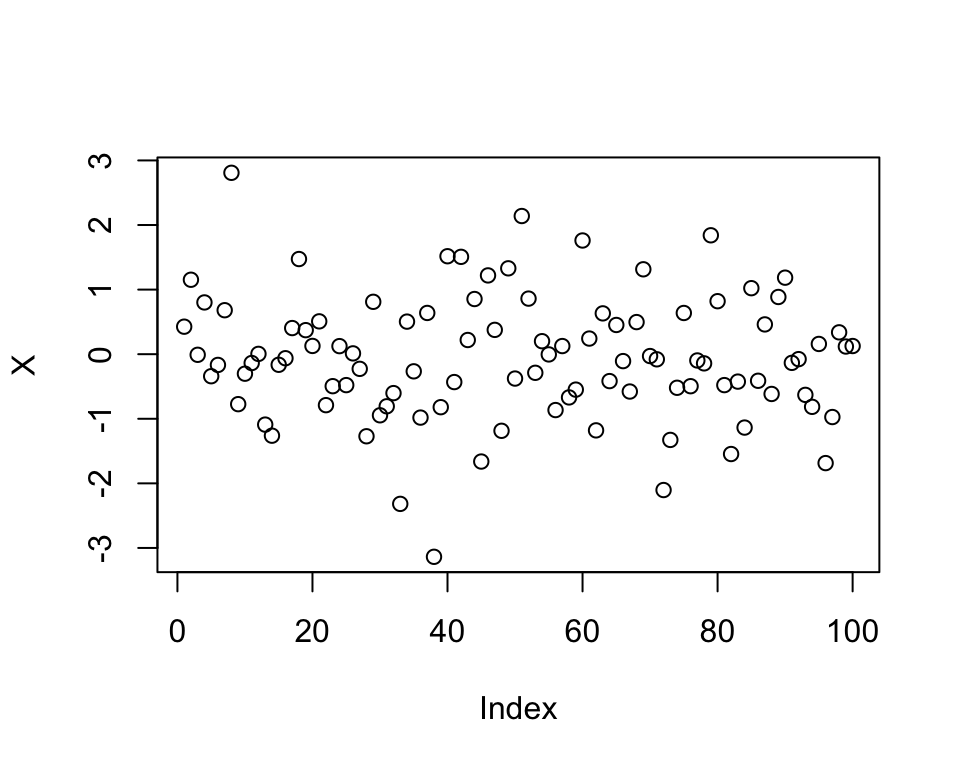

```r
set.seed(1453)
X <- rnorm(100, 0, 1)                # generate RS of size 100 from N(mean=0,SD=1)
plot(X)                              # scatter plot with dots
```

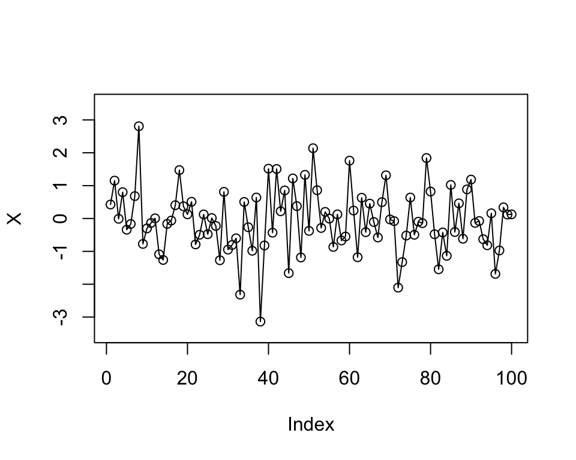

```r
plot(X,type='o', ylim=c(-3.5, 3.5))  # change type and zoom out on y-axis
```

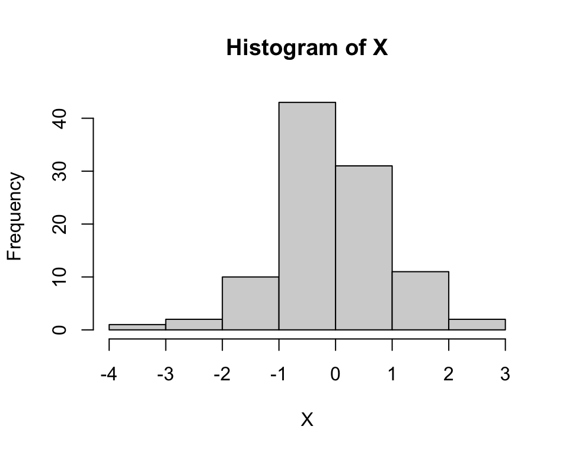

```r
hist(X)                              # histogram of X
```

### Inference for Random Sample

Using the two formulas, we get the statistical inference for the simulated sample above.

```r
mean(X)
```

```
## [1] -0.05789066
```

```r
sd(X)
```

```
## [1] 0.9623882
```

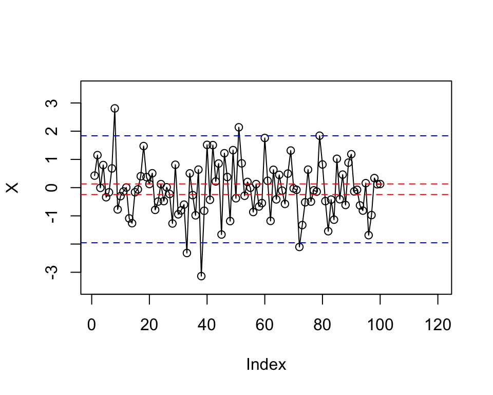

```r
#- compute CI
upper_CI = mean(X) + 1.96 * sd(X) * sqrt(1/100)
lower_CI = mean(X) - 1.96 * sd(X) * sqrt(1/100)

#- compute PI
upper_PI = mean(X) + 1.96 * sd(X) * sqrt(1/100 + 1)
lower_PI = mean(X) - 1.96 * sd(X) * sqrt(1/100 + 1)


plot(X,type='o', ylim=c(-3.5, 3.5), xlim=c(1,120))   # same plot as before
abline(h=upper_CI, col="red",  lty=2)           # add red dashed lines for CI
abline(h=lower_CI, col="red",  lty=2)
abline(h=upper_PI, col="blue", lty=2)           # add blue dashed lines for PI
abline(h=lower_PI, col="blue", lty=2)
```

This is all we can do to **forecast** if the data is random sample.

## 2. Example of Time Series

First, let’s load the package called **TSA** this is the package that comes with Cryer’s textbook.

```r
# required only the first time you use the package
install.packages("TSA")    # if asked to choose CRAN mirror, choose MI or OH site
```

```r
# required every time you restart R
acf1 <- acf        # Keep original acf() function
library(TSA)       # load package TSA
acf <- acf1        # replace back the new acf with original
```

### LA rainfall (p2)

Now load the data that comes with TSA package. Here’s the data for annual rain falls in LA.

```r
  data(larain)       # load dataset called larain that is in TSA package
  is.ts(larain)      # is larain TS object?
```

```
## [1] TRUE
```

```r
  larain             # see what's inside larain
```

```
## Time Series:
## Start = 1878
## End = 1992
## Frequency = 1
##   [1] 20.86 17.41 18.65  5.53 10.74 14.14 40.29 10.53 16.72 16.02 20.82 33.26 12.69
##  [14] 12.84 18.72 21.96  7.51 12.55 11.80 14.28  4.83  8.69 11.30 11.96 13.12 14.77
##  [27] 11.88 19.19 21.46 15.30 13.74 23.92  4.89 17.85  9.78 17.17 23.21 16.67 23.29
##  [40]  8.45 17.49  8.82 11.18 19.85 15.27  6.25  8.11  8.94 18.56 18.63  8.69  8.32
##  [53] 13.02 18.93 10.72 18.76 14.67 14.49 18.24 17.97 27.16 12.06 20.26 31.28  7.40
##  [66] 22.57 17.45 12.78 16.22  4.13  7.59 10.63  7.38 14.33 24.95  4.08 13.69 11.89
##  [79] 13.62 13.24 17.49  6.23  9.57  5.83 15.37 12.31  7.98 26.81 12.91 23.66  7.58
##  [92] 26.32 16.54  9.26  6.54 17.45 16.69 10.70 11.01 14.97 30.57 17.00 26.33 10.92
## [105] 14.41 34.04  8.90  8.92 18.00  9.11 11.57  4.56  6.49 15.07 22.65
```

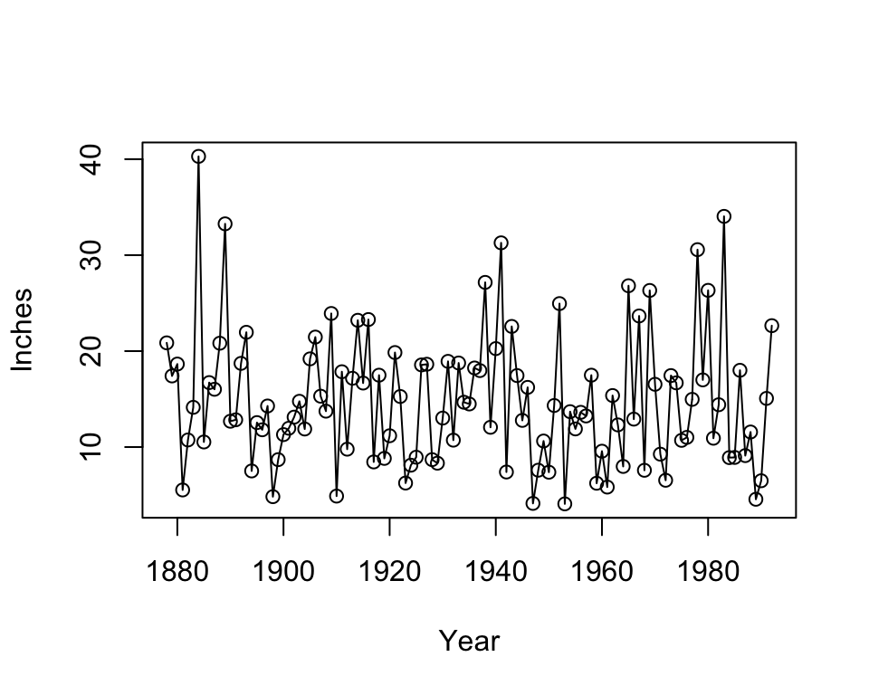

```r
  plot(larain,  ylab='Inches', xlab='Year', type='o')  # plot the data with labels
```

### Chemical Process (p3)

Here’s color peoperty of a chemicals mixed in a plant.

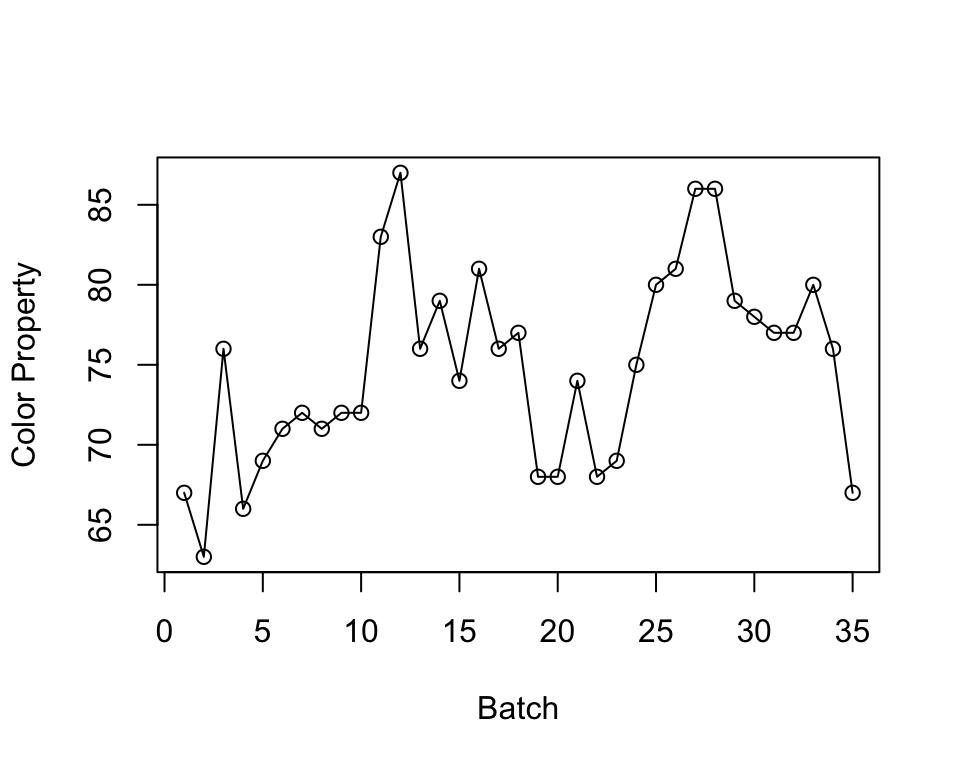

```r
  data(color)    # load dataset called color that is in TSA package
  plot(color,  ylab='Color Property',xlab='Batch',type='o')
```

### Abundance of Canadian Hare (p5)

Here’s annual population of rabbits in Canada

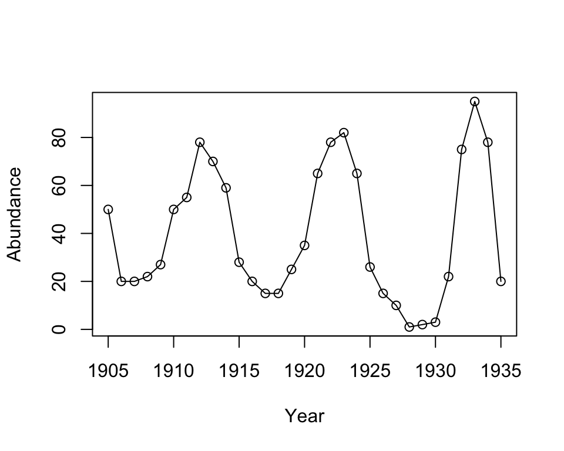

```r
  data(hare)    # load dataset
  plot(hare,ylab='Abundance',xlab='Year',type='o')
```

### Monthly Oil Filter Sales (p7)

Sales for oil filters

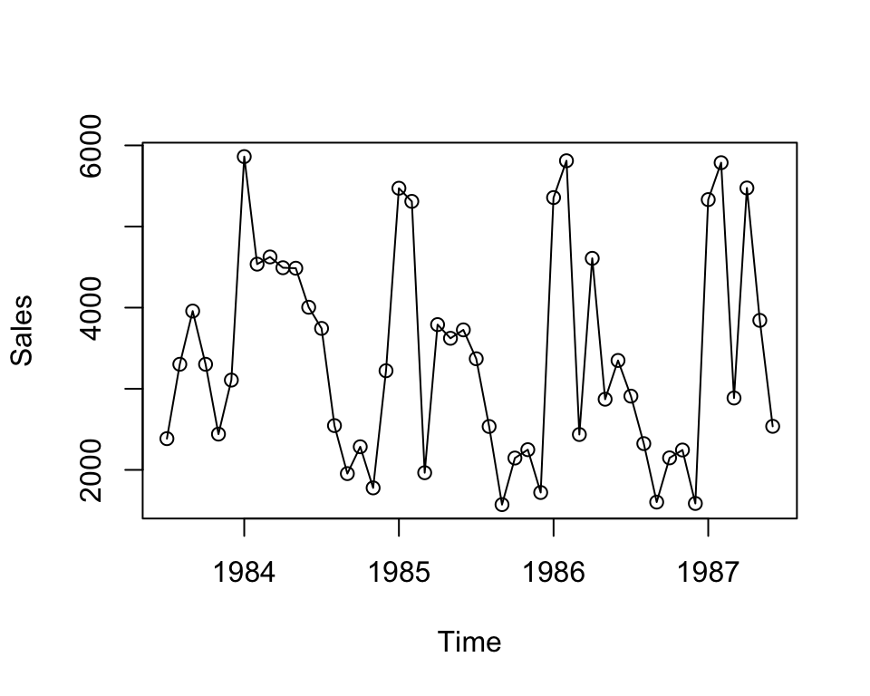

```r
  data(oilfilters)    # load dataset
  plot(oilfilters,type='o',ylab='Sales')
```

```r
  is.ts(oilfilters)      # is data in TS format?
```

```
## [1] TRUE
```

```r
  oilfilters             # see what's inside oilfilters
```

```
##       Jan  Feb  Mar  Apr  May  Jun  Jul  Aug  Sep  Oct  Nov  Dec
## 1983                               2385 3302 3958 3302 2441 3107
## 1984 5862 4536 4625 4492 4486 4005 3744 2546 1954 2285 1778 3222
## 1985 5472 5310 1965 3791 3622 3726 3370 2535 1572 2146 2249 1721
## 1986 5357 5811 2436 4608 2871 3349 2909 2324 1603 2148 2245 1586
## 1987 5332 5787 2886 5475 3843 2537
```

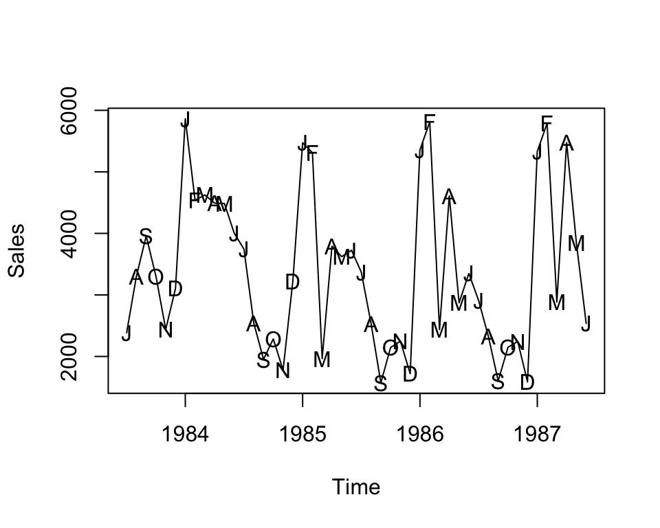

```r
  #-- Plot with month's initial letter
  plot(oilfilters,type='l',ylab='Sales')
  points(y=oilfilters,x=time(oilfilters), pch=as.vector(season(oilfilters)))
```

## 3. Difference Between RS and TS

### Back to Hare Data

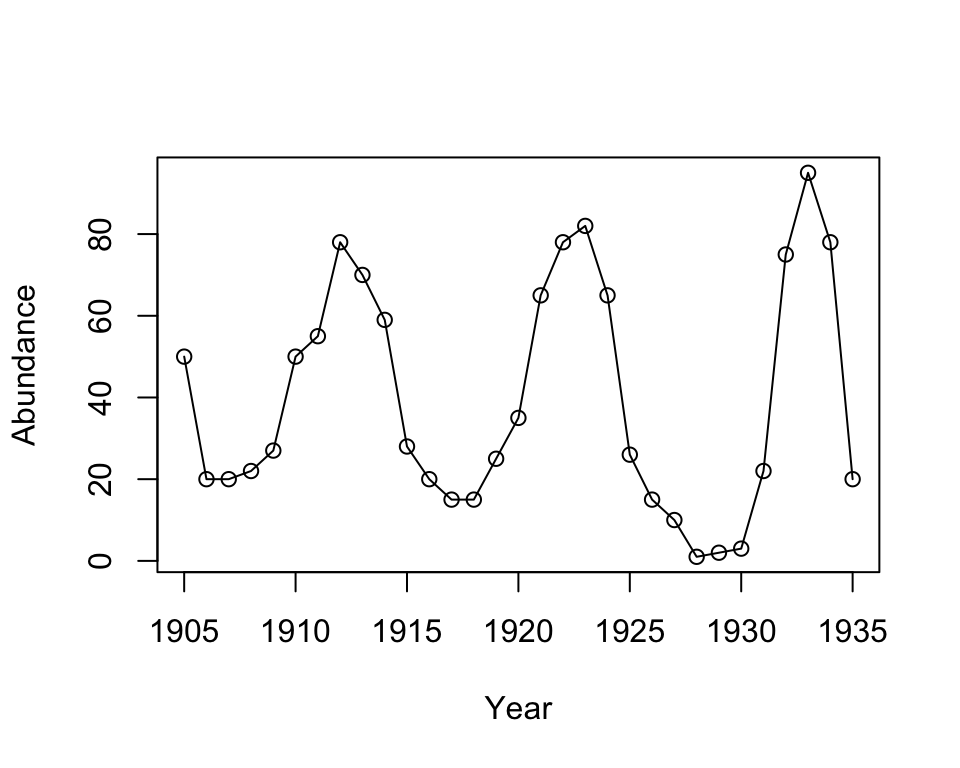

```r
plot(hare,ylab='Abundance',xlab='Year',type='o')
```

```r
length(hare)   # see how long is the hare data
```

```
## [1] 31
```

```r
hare           # show what's inside hare
```

```
## Time Series:
## Start = 1905
## End = 1935
## Frequency = 1
##  [1] 50 20 20 22 27 50 55 78 70 59 28 20 15 15 25 35 65 78 82 65 26 15 10  1  2  3
## [27] 22 75 95 78 20
```

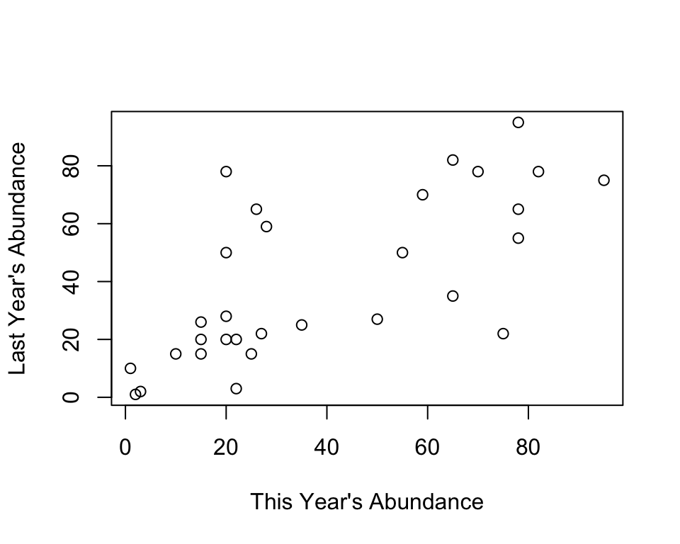

```r
#- This year vs Last Year
plot(x=hare[2:31], y=hare[1:30],
     ylab="Last Year's Abundance",
     xlab="This Year's Abundance")
```

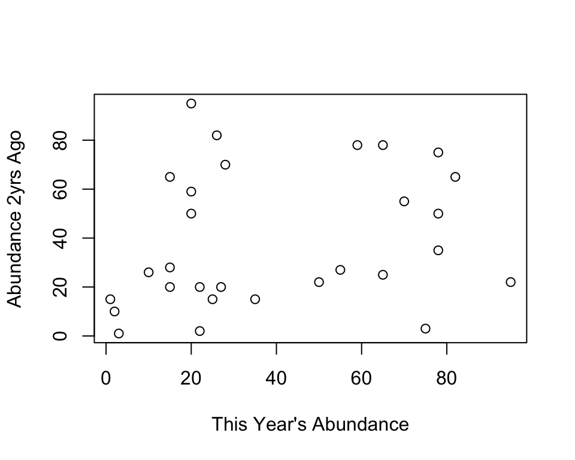

```r
#- This year vs 2 Years ago ---
plot(x=hare[3:31], y=hare[1:29],
     ylab="Abundance 2yrs Ago",
     xlab="This Year's Abundance")
```

### Chemical Process (p3)

Here’s color peoperty of a chemicals mixed in a plant.

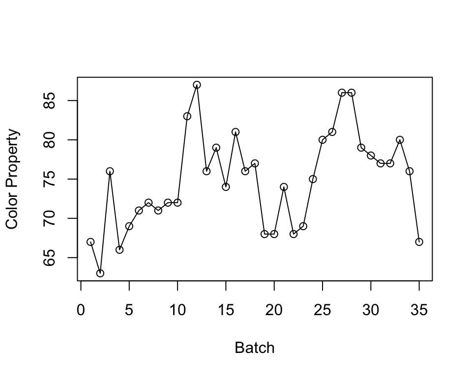

```r
data(color)       # load the dataset
plot(color,ylab='Color Property',xlab='Batch',type='o')
```

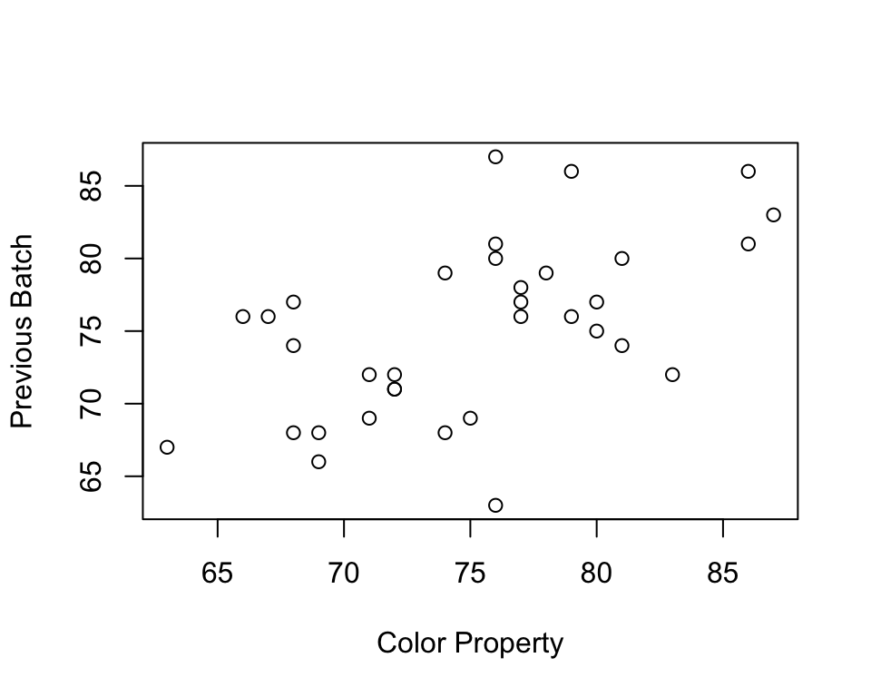

```r
#- Plot of color vs previous color
plot(x=color[2:35], y=color[1:34], xlab='Color Property', ylab='Previous Batch')
```

### Back Random Sample X

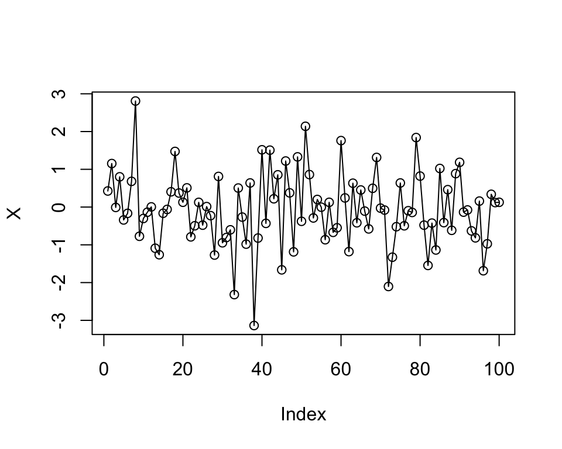

```r
plot(X, type='o')
```

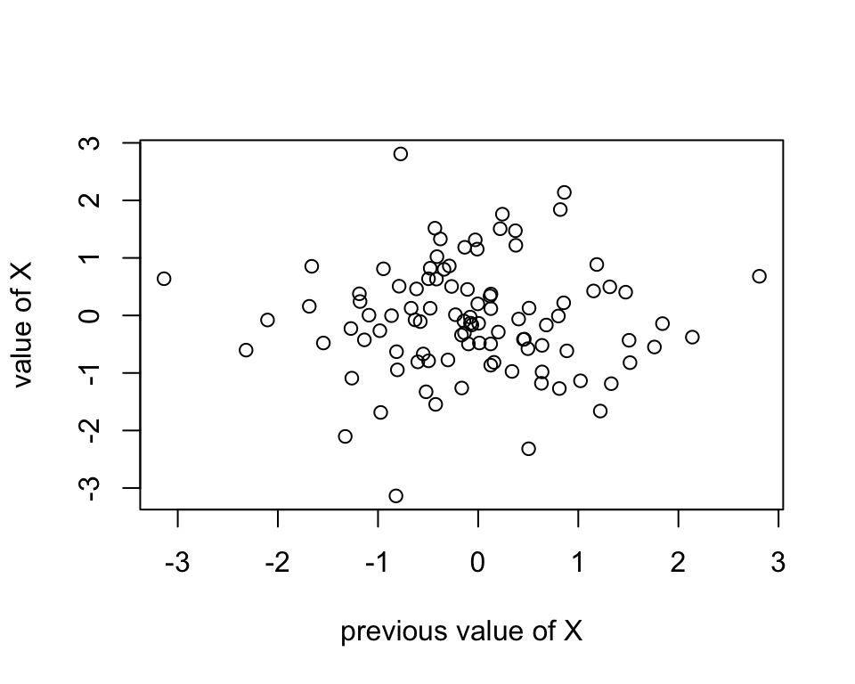

```r
#- Plot value of X agains previous value of X
plot(X[2:100], X[1:99], ylab='value of X', xlab='previous value of X')
```

Not so much pattern here.

## 4. Autocorrelation

To capture the pattern we saw between current vs previous values of **hare** data and **color** data, we use correlation.

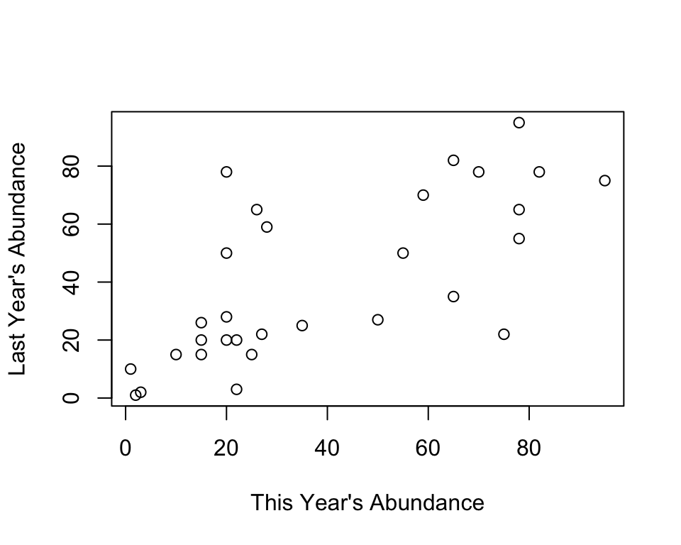

```r
#- Hare data This year vs Last Year
plot(x=hare[2:31], y=hare[1:30],
     ylab="Last Year's Abundance",
     xlab="This Year's Abundance")
```

```r
cor(hare[2:31], hare[1:30])    # Autocorrelation of Lag 1
```

```
## [1] 0.7025777
```

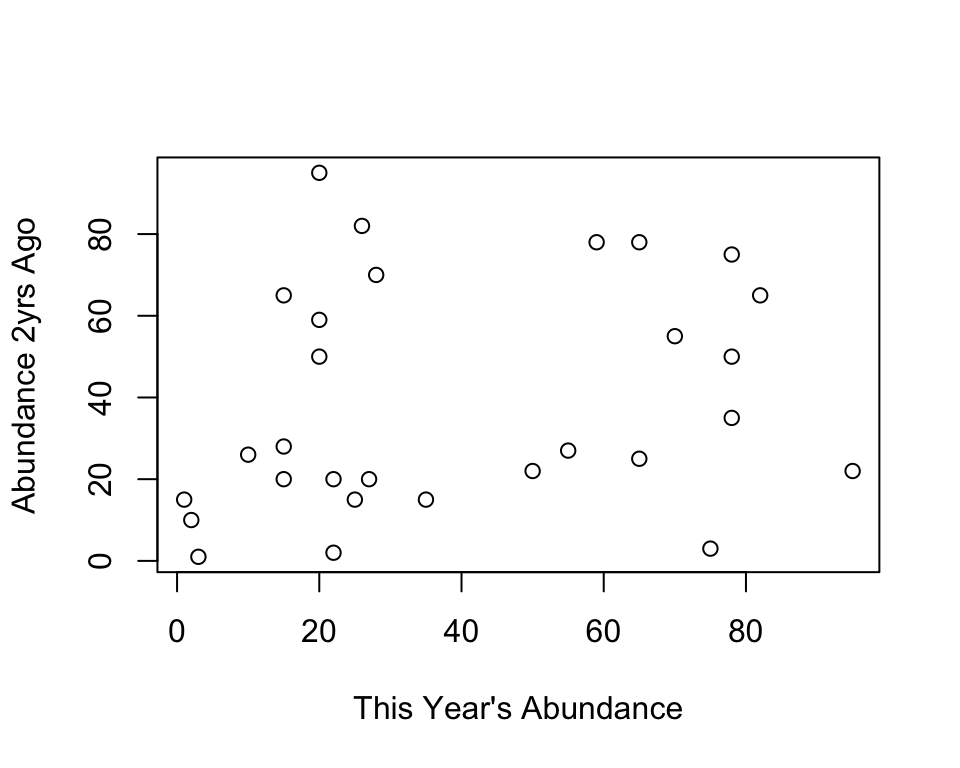

```r
#- Hare data This year vs 2 Years ago
plot(x=hare[3:31], y=hare[1:29],
  ylab="Abundance 2yrs Ago",
  xlab="This Year's Abundance")
```

```r
cor(hare[3:31], hare[1:29])    # Autocorrelation of Lag 2
```

```
## [1] 0.2244224
```

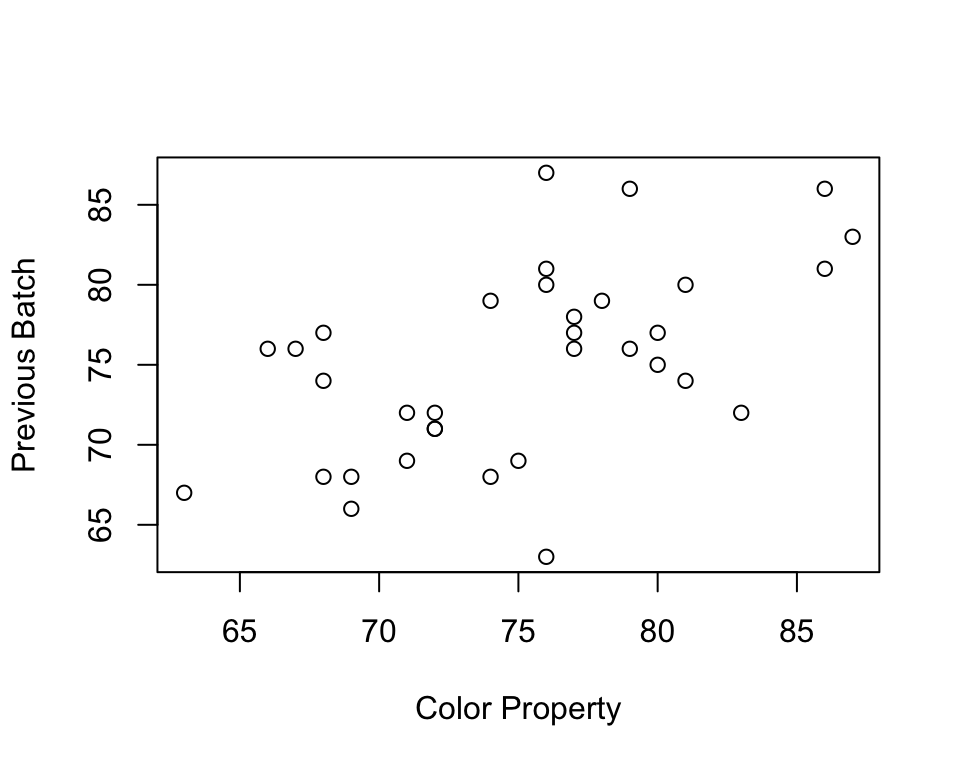

```r
#- Color data Plot of color vs previous color
plot(x=color[2:35], y=color[1:34], xlab='Color Property', ylab='Previous Batch')
```

```r
cor(color[2:35], color[1:34])  # Autocorrelation of Lag 1
```

```
## [1] 0.554917
```

This pattern doesn’t exist in **random sample X**.

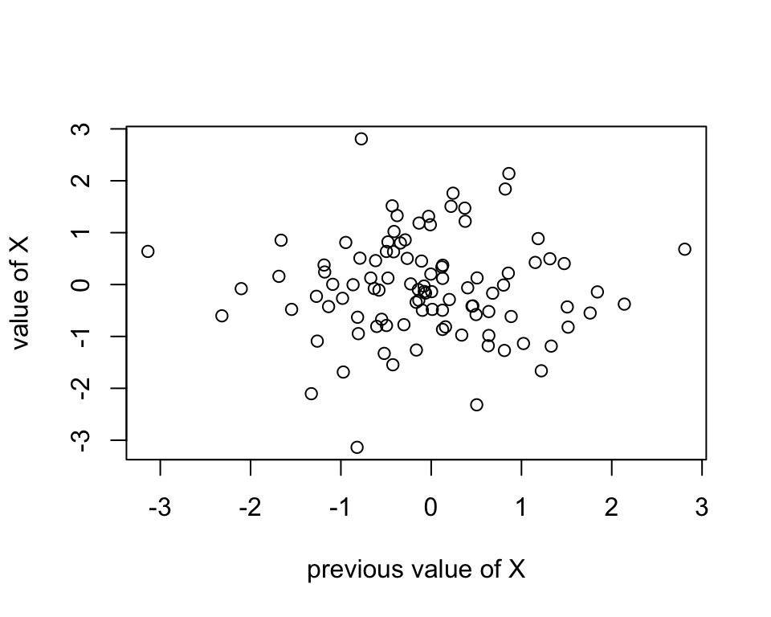

```r
  #-- Random Sample X:  Plot value of X agains previous value of X
  plot(X[2:100], X[1:99], ylab='value of X', xlab='previous value of X')
```

```r
  cor(X[2:100], X[1:99])         # Auto correlation of Lag 1
```

```
## [1] -0.002031602
```

### Autocorrelation Function (ACF)

**Autocorrelation Function** is a collection of all the autocorrelaton at all the different lags.

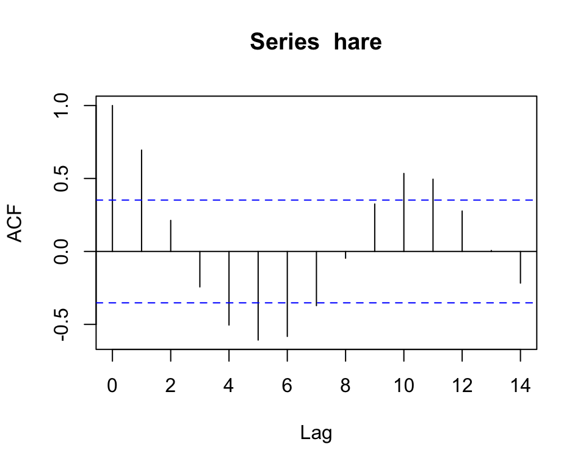

```r
  acf(hare)          # Autocorrelation Function of hare data
```

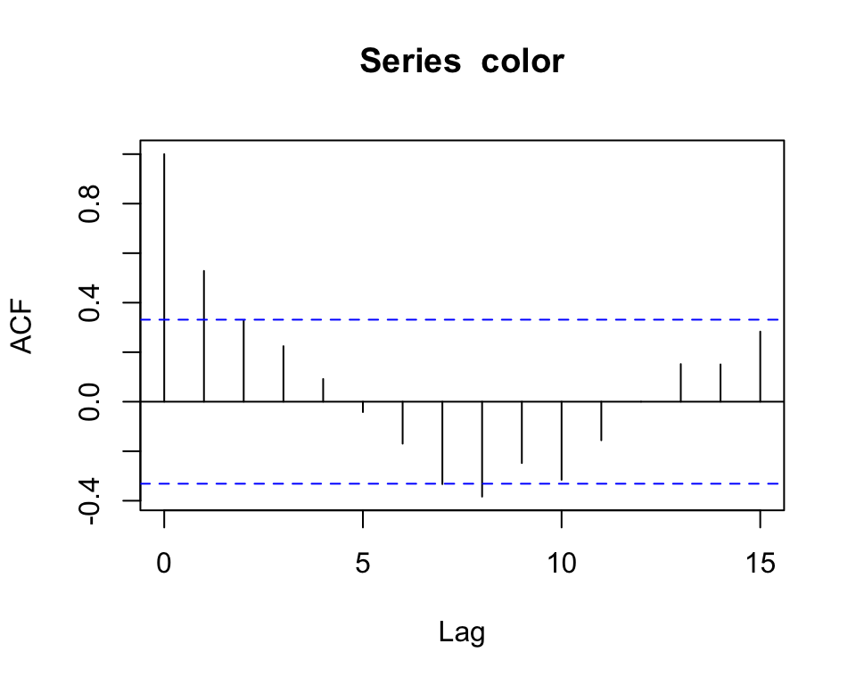

```r
  acf(color)         # Autocorrelation Function of color data
```

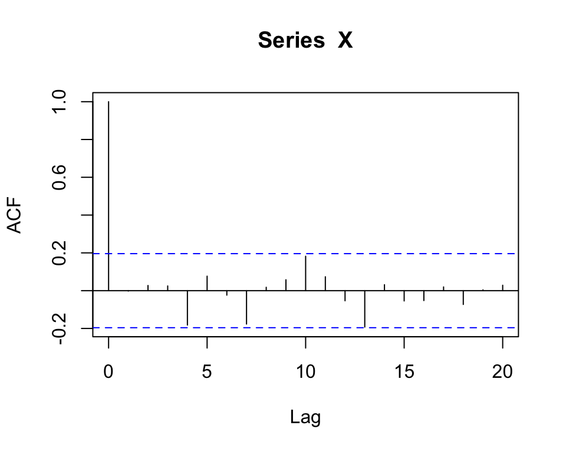

```r
  acf(X)             # Autocorrelation Functoin of RS X
```

## Summary

- What is the key difference between Time Series and Random Sample?
- How do you check if a data is random sample, and not time series?